# Untitled

Dr. B

Saturday, January 17, 2015

## Kappa Coefficient

The kappa coefficient (K) measures pairwise agreement among a set of coders making category judgments, correcting for expected chance agreement.

K = P(A) - P(P) / 1 - P(E)

When there is no agreement other than that which would be expected by chance K is zero. When there is total agreement, K is one. When it is useful to do so, it is possible to test whether or not K is significantly different from chance, but more importantly, interpretation of the scale of agreement is possible.

## Example

Suppose that you were analyzing data related to a group of 50 people applying for a grant. Each grant proposal was read by two readers and each reader either said “Yes” or “No” to the proposal.

Suppose the dis/agreement count data were as follows, where A and B are readers, data on the diagonal slanting left shows the count of agreements and the data on the diagonal slanting right, disagreements:

```r
x <-matrix(c(20,5,10,15),ncol=2,byrow=TRUE)
colnames(x) <- c("Yes","No")
rownames(x) <- c("Yes","No")
x <- as.table(x)
x
```

```
##     Yes No
## Yes  20  5
## No   10 15
```

```r
margin.table(x)
```

```
## [1] 50
```

```r
margin.table(x,1)
```

```
## Yes  No
##  25  25
```

```r
margin.table(x,2)
```

```
## Yes  No
##  30  20
```

```r
x/margin.table(x)
```

```
##     Yes  No
## Yes 0.4 0.1
## No  0.2 0.3
```

```r
prop.table(x)
```

```
##     Yes  No
## Yes 0.4 0.1
## No  0.2 0.3
```

```r
margin.table(x,1)/margin.table(x)
```

```
## Yes  No
## 0.5 0.5
```

```r
margin.table(x,2)/margin.table(x)
```

```
## Yes  No
## 0.6 0.4
```

```r
prop.table(x,1)
```

```
##     Yes  No
## Yes 0.8 0.2
## No  0.4 0.6
```

```r
prop.table(x,2)
```

```
##           Yes        No
## Yes 0.6666667 0.2500000
## No  0.3333333 0.7500000
```

```r
summary(x)
```

```
## Number of cases in table: 50
## Number of factors: 2
## Test for independence of all factors:
##  Chisq = 8.333, df = 1, p-value = 0.003892
```

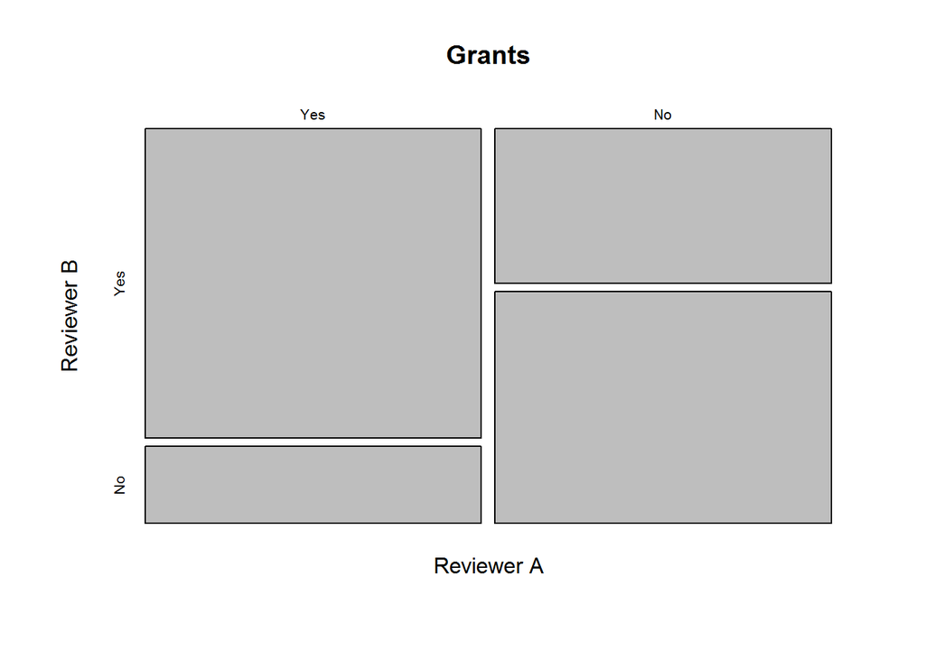

```r
mosaicplot(x,main="Grants",xlab="Reviewer A",ylab="Reviewer B")
```

Note that there were 20 proposals that were granted by both reader A and reader B, and 15 proposals that were rejected by both readers. Thus, the observed percentage agreement is Pr(a) = (20 + 15) / 50 = 0.70

To calculate Pr(e) (the probability of random agreement) we note that:

Reader A said “Yes” to 25 applicants and “No” to 25 applicants. Thus reader A said “Yes” 50% of the time. Reader B said “Yes” to 30 applicants and “No” to 20 applicants. Thus reader B said “Yes” 60% of the time.

Therefore the probability that both of them would say “Yes” randomly is 0.50 x 0.60 = 0.30 and the probability that both of them would say “No” is 0.50 x 0.40 = 0.20. Thus the overall probability of random agreement is Pr(E) = 0.3 + 0.2 = 0.5.

So now applying our formula for Cohen’s Kappa we get:

```
    .7 - .5 / 1 - .5 = .4
```

## Interpreting K

The K value can be interpreted as follows (Altman, 1991):

```
    Value of K        Strength of agreement
    < 0.20                  Poor
    0.21 - 0.40         Fair
    0.41 - 0.60         Moderate
    0.61 - 0.80         Good
    0.81 - 1.00         Very good
```